# IBD and IEI

Inflammatory Bowel Disease and Inborn Errors of Immunity

Peter N Robinson, Dominik Seelow, Katy Börner

Berlin Institute of Health

2026-10-26

## Background

Data-Driven Differential Diagnosis in Human Genetics

**Today’s talk**  
How human genetics uses data science and genomics to support differential diagnostics

**The diagnostic rate** in human genetics has improved by roughly **300%** in the last two decades

**Our example**  
A patient with a Mendelian mimic of inflammatory bowel disease<sup>1</sup>

[^1]: chronisch-entzündliche Darmerkrankung (abgekürzt CED)

## IBD: Rare and common

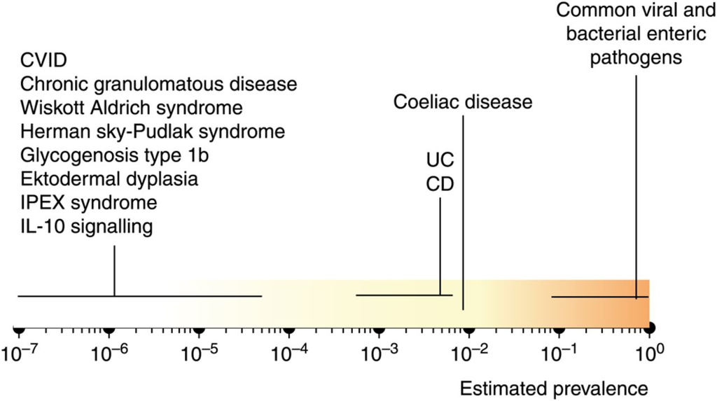

**Common**  
Intestinal infections that nearly everyone gets once in a while

**Crohn disease (CD) and ulcerative colitis (UC)**  
Together termed inflammatory bowel disease (IBD), ca. 1:200 individuals

**Rare**  
Inborn errors of immunity (IEI), monogenic diseases that can present with IBD-like immunopathology, often severe and early-onset

image: Uhlig HH. Monogenic diseases associated with intestinal inflammation: implications for the understanding of inflammatory bowel disease. Gut. 2013 PMID: 24203055.

## IBD: Pathways

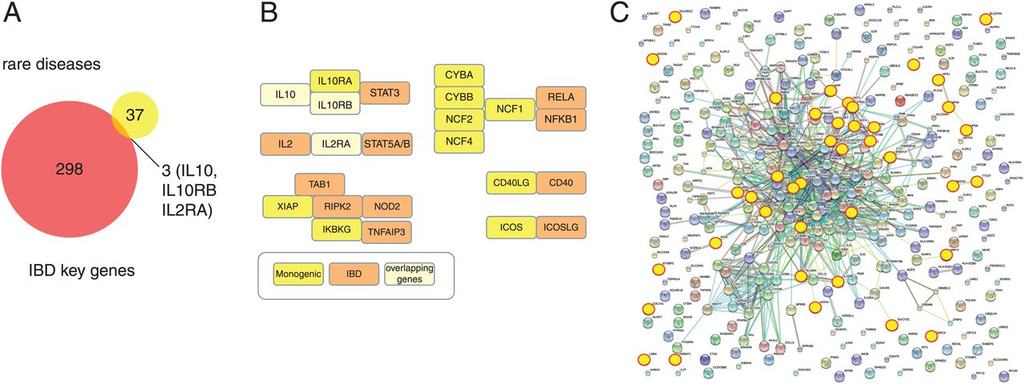

Pathway interaction between key genes associated with inflammatory bowel disease (IBD) and IBD-like monogenic disorders

Understanding rare diseases with IBD-like features may provide insight for treating common forms

image: Uhlig HH. Monogenic diseases associated with intestinal inflammation: implications for the understanding of inflammatory bowel disease. Gut. 2013 PMID: 24203055.

## IBD: Pathophysiology

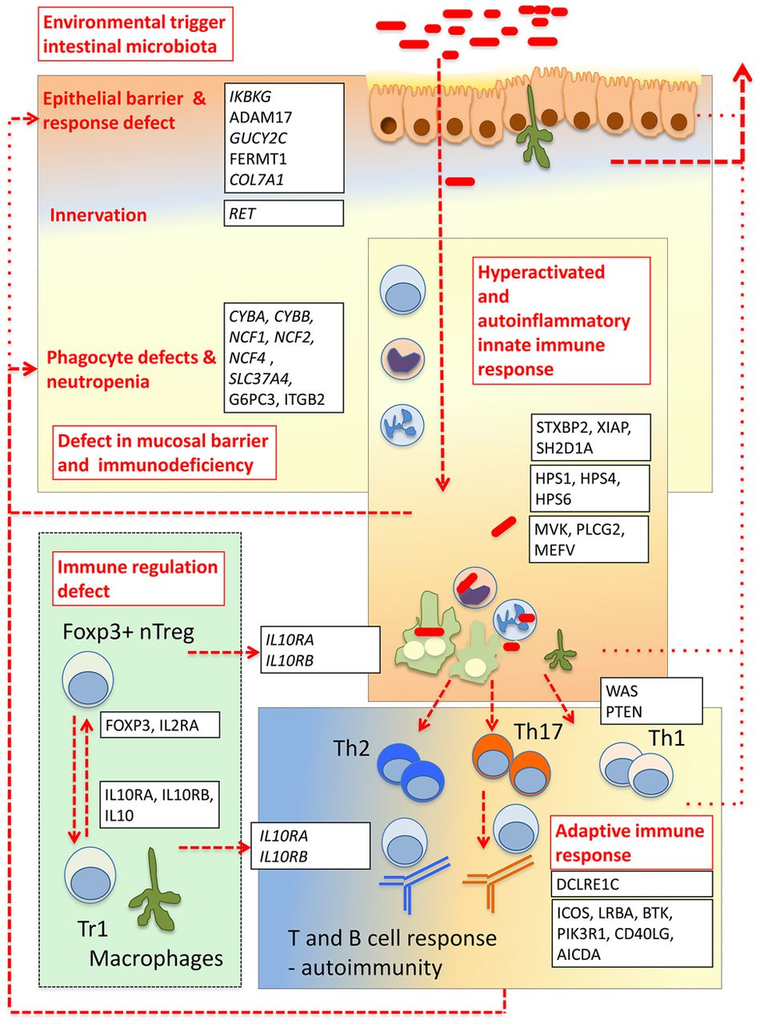

**The model**  
Key intestinal defence functions and cellular immune regulation components are impaired in monogenic disorders with an IBD-like phenotype

**The defects**  
Epithelial barrier and response, neutrophil numbers, phagocytosis and bacterial killing, and gut innervation. Together they increase bacterial translocation across the epithelium and bacterial survival

image: Uhlig HH. Monogenic diseases associated with intestinal inflammation: implications for the understanding of inflammatory bowel disease. Gut. 2013 PMID: 24203055.

## Rare in common

Is “common disease” always what it seems?

**70 of 1480 (4.73%)** participants with IBD, from five clinical trials, had pathogenic or likely pathogenic variants in a relevant gene

**31 of 33** of those with a rare disease-causing variant showed no or only a short-term response to adalimumab, a TNF-α inhibitor approved by the FDA for Crohn’s disease and ulcerative colitis

In clinical practice, rare forms of common disease may be difficult to recognize. **Misdiagnoses of rare diseases as common ones are not infrequent.**

- [Rahimov F, et al. (2025) Common Diseases in Clinical Cohorts - Not Always What They Seem. *N Engl J Med* **393**:1589-1598](https://pubmed.ncbi.nlm.nih.gov/41124632/)
- [Robinson PN (2025) A Rare-in-Common Paradigm for Precision Genomic Medicine. *N Engl J Med* **393**:1648-1649](https://pubmed.ncbi.nlm.nih.gov/41124636/)